# YRBS_Analysis

Michael Perez, Seth Galluci, Brian Bellamy, Harold Gonzalez

2025-12-02

#Data Cleaning

Ensured ordinals are all worse = higher, flipped binaries from 1-2 to 0-1 to match.

```
##
##    1    2    3    4    5    6    7 <NA>
## 1082  637  708  904 5888 1181 4803 4900
```

```
##
##    1    2    3    4    5    6    7 <NA>
## 1082  637  708  904 5888 1181 4803 4900
```

```
##    Variable Level     Estimate      P_Value
## 1       Q42   Q42  0.227558890 5.971239e-06
## 2       Q33   Q33  0.113343202 4.390180e-02
## 3       Q36   Q36  0.178644330 7.476531e-15
## 4       Q93   Q93  0.031348840 4.738292e-01
## 5       Q56   Q56  0.514338011 1.654183e-11
## 6       Q16   Q16  0.017115080 6.273159e-01
## 7       Q12   Q12 -0.006012586 8.677381e-01
## 8       Q24   Q24  0.079849500 6.757381e-01
## 9       Q26   Q26  0.342573340 2.370511e-03
## 10      Q27   Q27  0.098567092 5.783966e-01
## 11      Q84   Q84  0.258577428 1.554514e-04
## 12      Q87   Q87  0.134366716 1.295052e-05
```

```
##     Variable Level      Estimate      P_Value
## 1         Q1   Q80  0.0137402462 3.031755e-01
## 2         Q2   Q80  0.0285470693 3.838142e-08
## 3         Q3   Q80  0.0098361170 3.780205e-01
## 4         Q4   Q80  0.0061872107 4.018102e-01
## 5         Q6   Q80 -0.0028271965 1.844871e-02
## 6         Q7   Q80 -0.0119384262 9.124380e-01
## 7         Q8   Q80 -0.0217289562 1.135554e-01
## 8         Q9   Q80  0.0197734605 9.182818e-02
## 9        Q10   Q80  0.0168795188 4.994183e-03
## 10       Q11   Q80  0.1112615964 1.145504e-07
## 11       Q12   Q80 -0.0007083103 8.690698e-01
## 12       Q13   Q80 -0.0021509027 6.507586e-01
## 13       Q14   Q80  0.0143998020 1.245542e-01
## 14       Q15   Q80  0.0140680838 9.121388e-02
```

[output cut: 91 more lines]

```
##
##     1     2     3     4     5     6     7  <NA>
## 15050  2377   882   439   250    71   133   901
```

```
##        0 days   1 or 2 days   3 to 5 days   6 to 9 days 10 to 19 days
##             1             2             3             4             5
## 20 to 29 days   All 30 days
##             6             7
```

```
##
## ==============================
## Variable: Q12
## Label: Weapon carrying at school
## Value Labels:
##         0 days          1 day    2 or 3 days    4 or 5 days 6 or more days
##              1              2              3              4              5
## Frequencies:
##
##     1     2     3     4     5  <NA>
## 18747   203   168    63   414   508
##
## ==============================
## Variable: Q16
## Label: Times in fight past 12 months
## Value Labels:
##          0 times           1 time     2 or 3 times     4 or 5 times
##                1                2                3                4
##     6 or 7 times     8 or 9 times   10 or 11 times 12 or more times
##                5                6                7                8
## Frequencies:
##
##    1    2    3    4    5    6    7    8 <NA>
## 9309 1100  748  225   67   35   15  153 8451
##
## ==============================
## Variable: Q24
## Label: Bullied at school
## Value Labels:
##  No Yes
##   0   1
## Frequencies:
##
##     0     1  <NA>
## 15856  4046   201
##
## ==============================
## Variable: Q26
## Label: Sad or hopeless
## Value Labels:
```

[output cut: 88 more lines]

```
##    1    2    3    4    5 <NA>
## 6585 5094 2667  842  506 4409
##
## ==============================
## Variable: Q93
## Label: Ever used hallucinogenic drugs
## Value Labels:
##          0 times     1 or 2 times     3 to 9 times   10 to 19 times
##                1                2                3                4
##   20 to 39 times 40 or more times
##                5                6
## Frequencies:
##
##     1     2     3     4     5     6  <NA>
## 10441   381   188    57    28    76  8932
```

Plotting

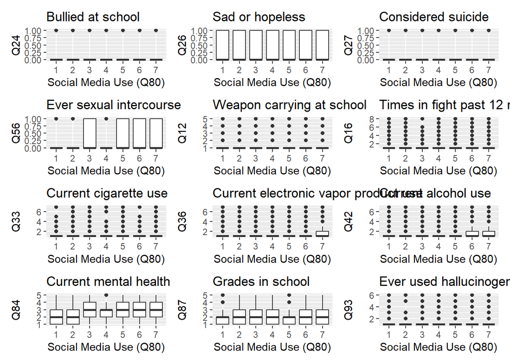

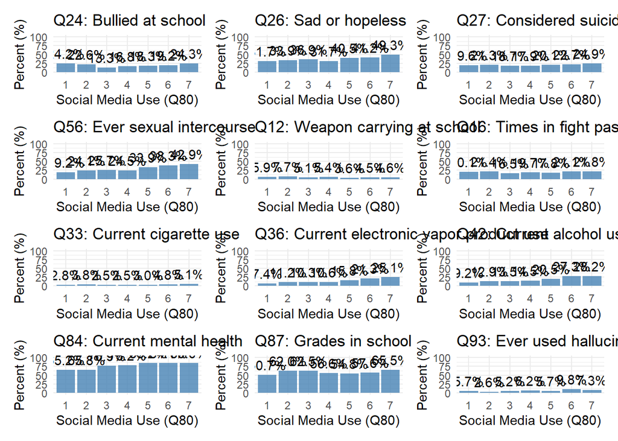

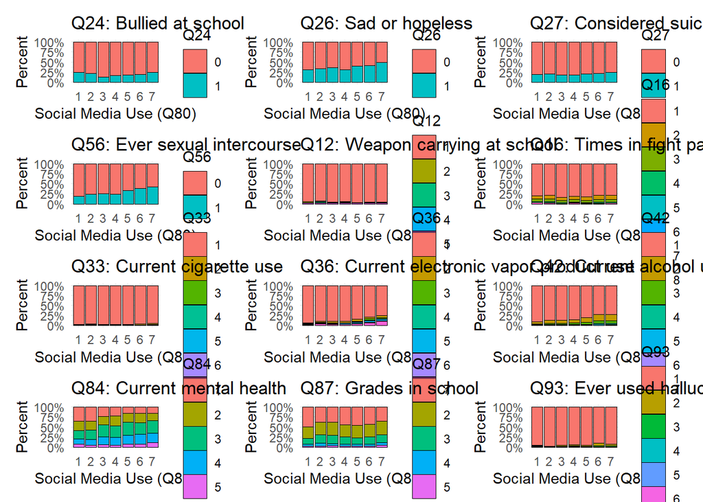

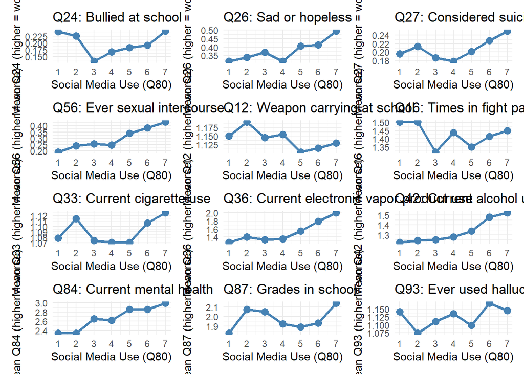

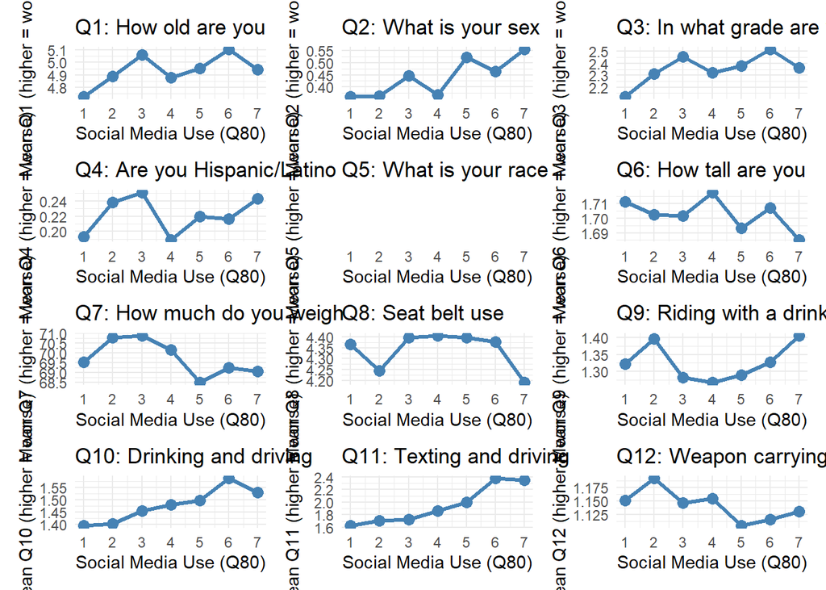

```r
current_Q_vars <- paste0("Q", 1:12)
mean_plots <- lapply(current_Q_vars, make_mean_plot)
wrap_plots(plotlist = mean_plots, ncol = 3)
```

[figure not shown]

```r
stacked_plots <- lapply(current_Q_vars, function(v) {
  make_stacked_bar(v)
})

wrap_plots(plotlist = stacked_plots, ncol = 3)
```

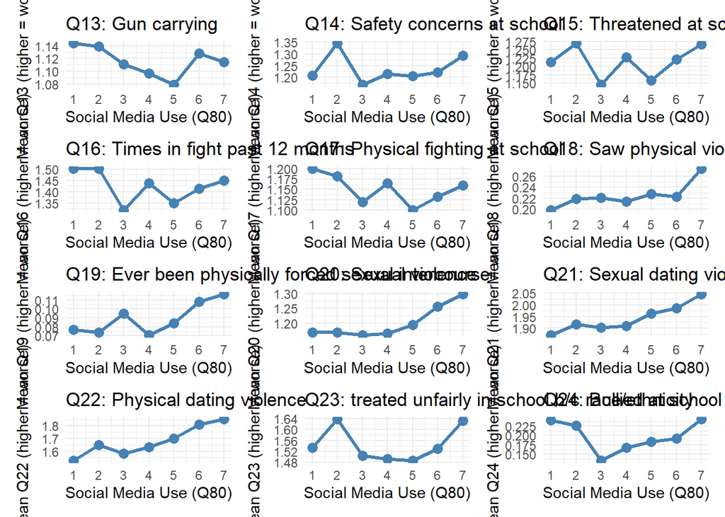

```r
current_Q_vars <- paste0("Q", 13:24)
mean_plots <- lapply(current_Q_vars, make_mean_plot)
wrap_plots(plotlist = mean_plots, ncol = 3)
```

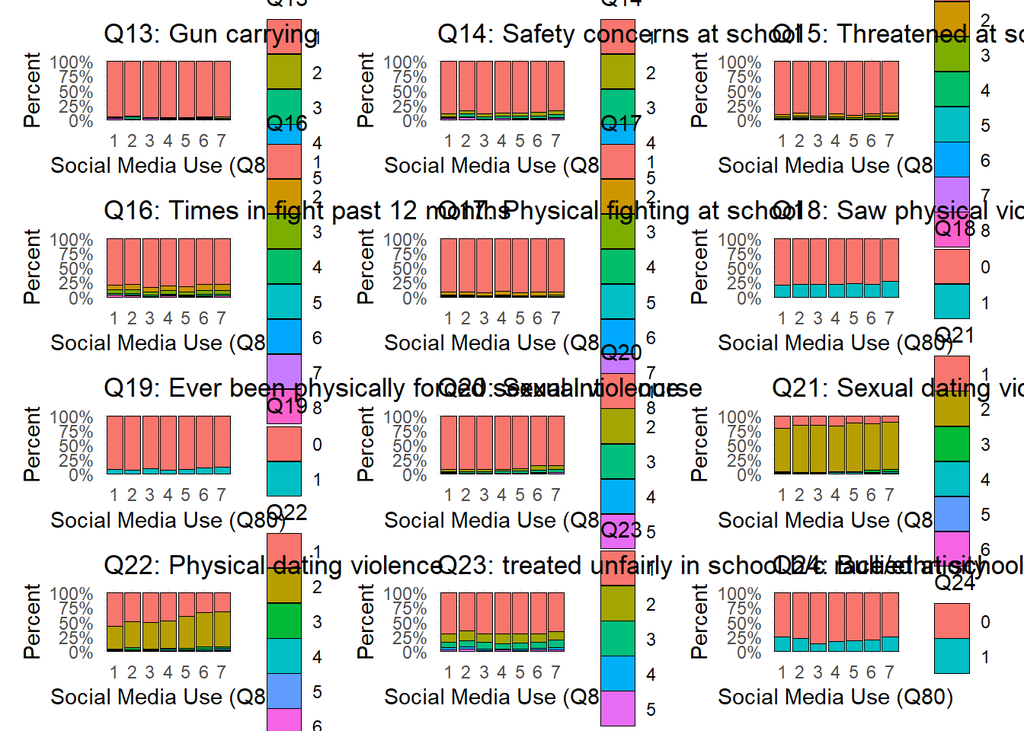

```r
stacked_plots <- lapply(current_Q_vars, function(v) {
  make_stacked_bar(v)
})

wrap_plots(plotlist = stacked_plots, ncol = 3)
```

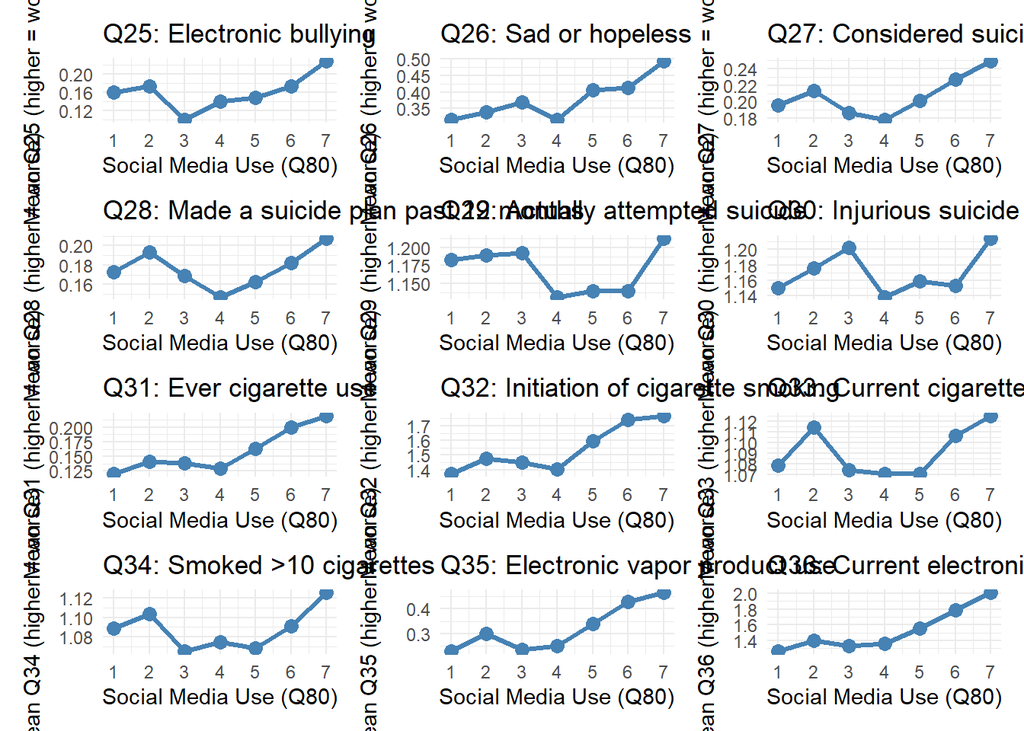

```r
current_Q_vars <- paste0("Q", 25:36)
mean_plots <- lapply(current_Q_vars, make_mean_plot)
wrap_plots(plotlist = mean_plots, ncol = 3)
```

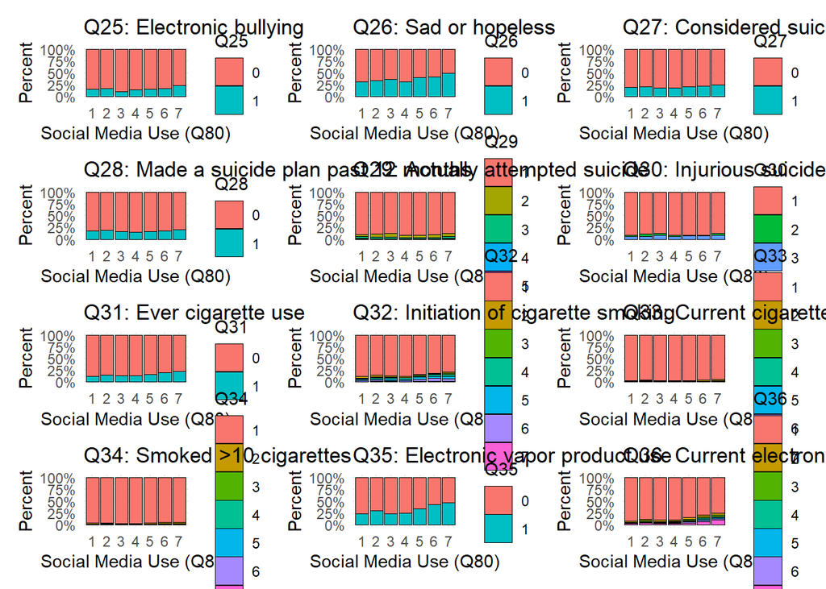

```r
stacked_plots <- lapply(current_Q_vars, function(v) {
  make_stacked_bar(v)
})

wrap_plots(plotlist = stacked_plots, ncol = 3)
```

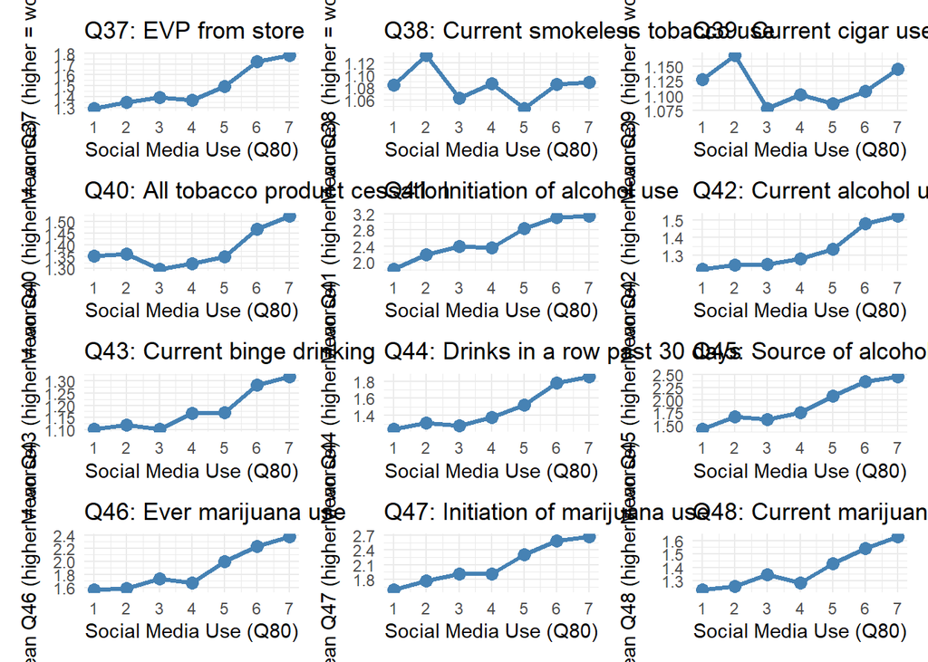

```r
current_Q_vars <- paste0("Q", 37:48)
mean_plots <- lapply(current_Q_vars, make_mean_plot)
wrap_plots(plotlist = mean_plots, ncol = 3)
```

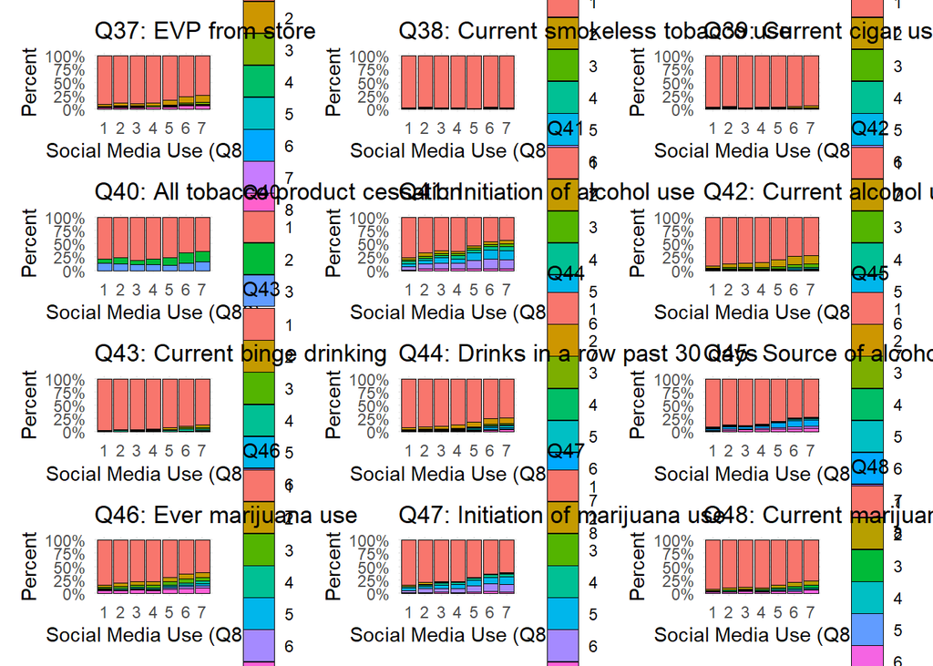

```r
stacked_plots <- lapply(current_Q_vars, function(v) {
  make_stacked_bar(v)
})

wrap_plots(plotlist = stacked_plots, ncol = 3)
```

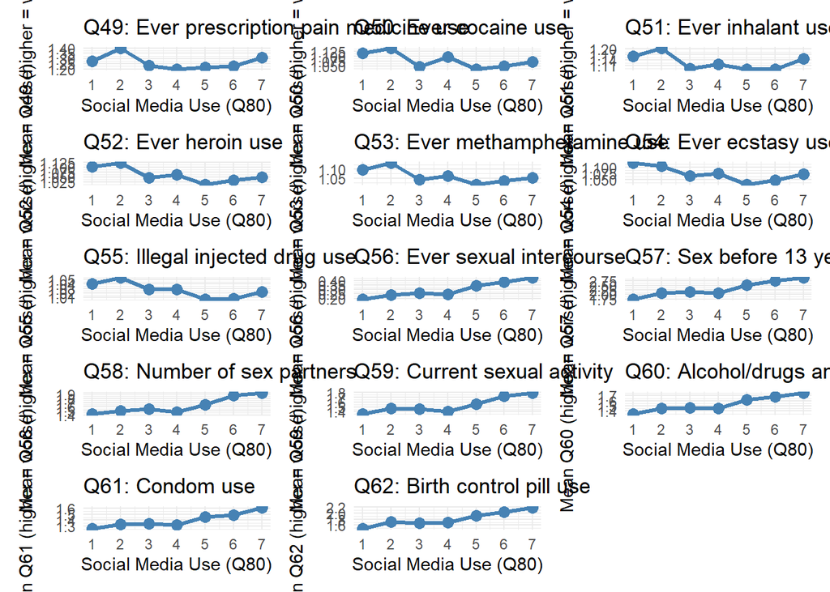

```r
current_Q_vars <- paste0("Q", 49:62)
mean_plots <- lapply(current_Q_vars, make_mean_plot)
wrap_plots(plotlist = mean_plots, ncol = 3)
```

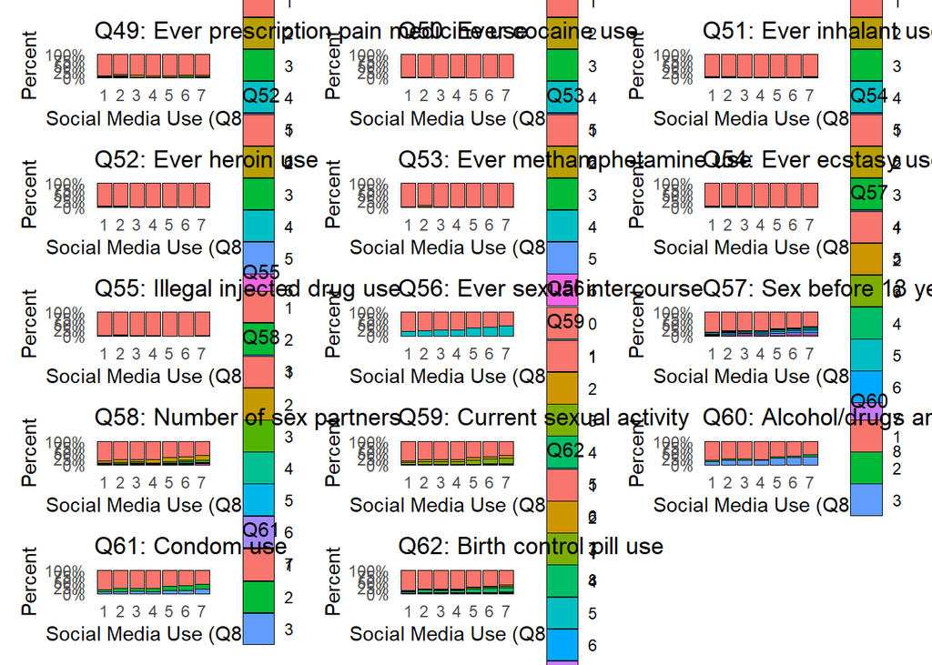

```r
stacked_plots <- lapply(current_Q_vars, function(v) {
  make_stacked_bar(v)
})

wrap_plots(plotlist = stacked_plots, ncol = 3)
```

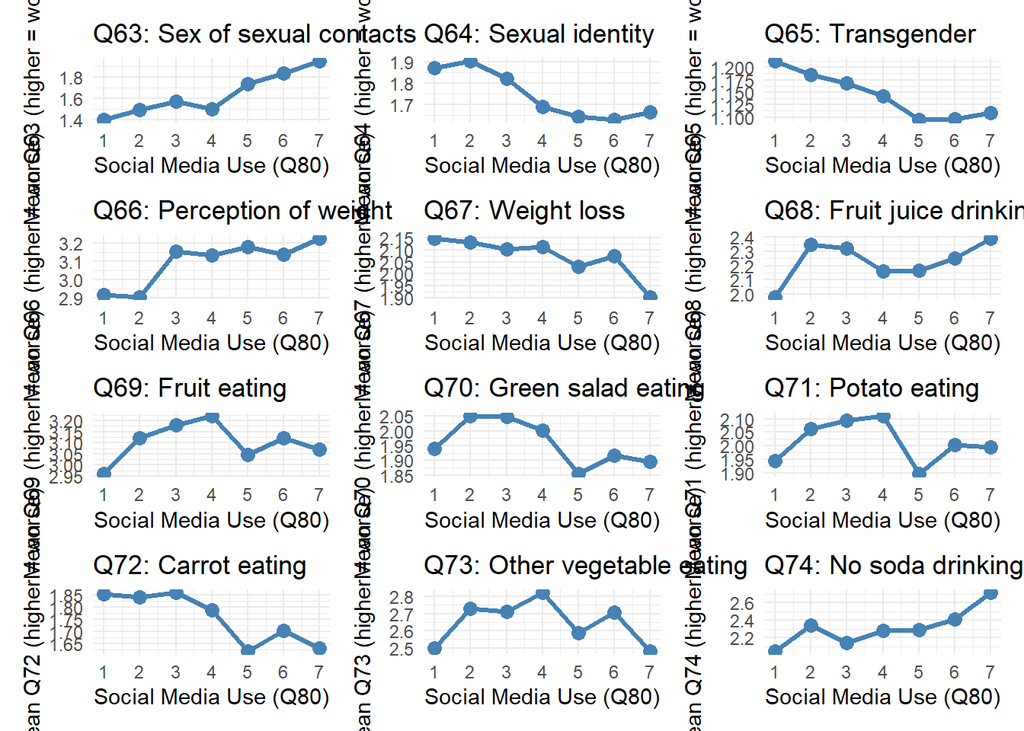

```r
current_Q_vars <- paste0("Q", 63:74)
mean_plots <- lapply(current_Q_vars, make_mean_plot)
wrap_plots(plotlist = mean_plots, ncol = 3)
```

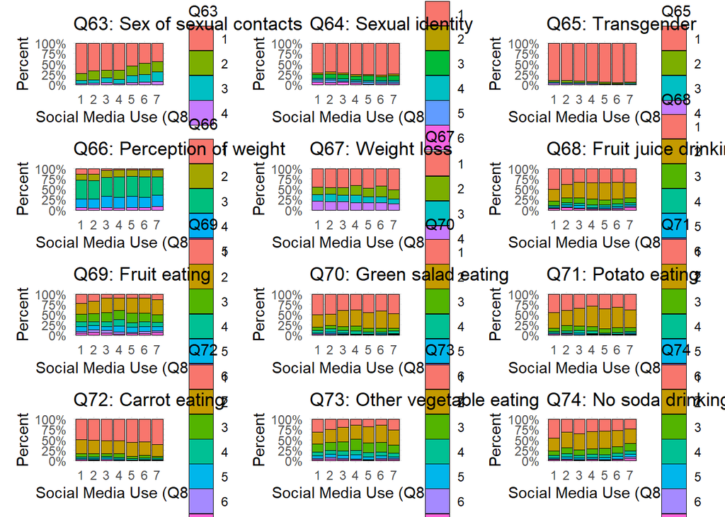

```r
stacked_plots <- lapply(current_Q_vars, function(v) {
  make_stacked_bar(v)
})

wrap_plots(plotlist = stacked_plots, ncol = 3)
```

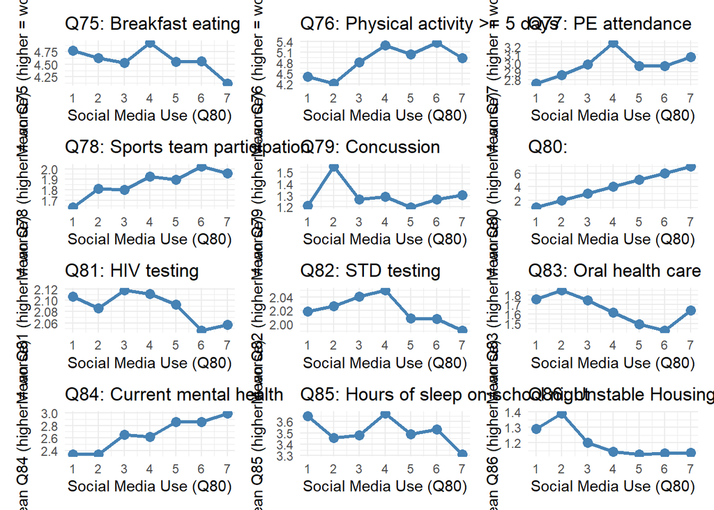

```r
current_Q_vars <- paste0("Q", 75:86)
mean_plots <- lapply(current_Q_vars, make_mean_plot)
wrap_plots(plotlist = mean_plots, ncol = 3)
```

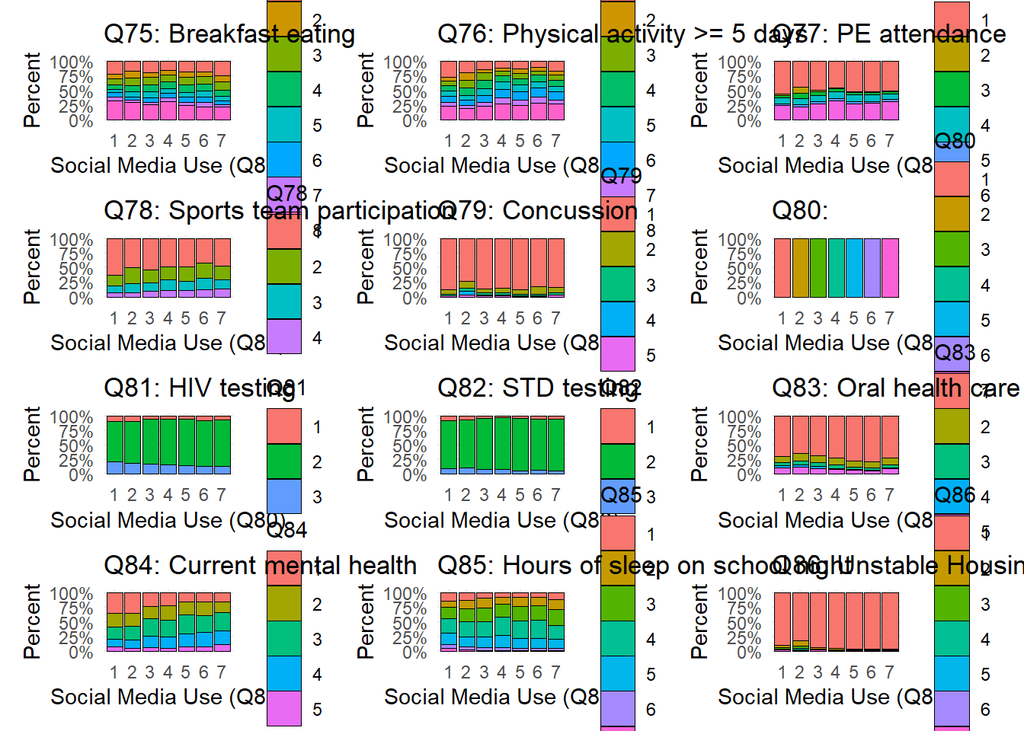

```r
stacked_plots <- lapply(current_Q_vars, function(v) {
  make_stacked_bar(v)
})

wrap_plots(plotlist = stacked_plots, ncol = 3)
```

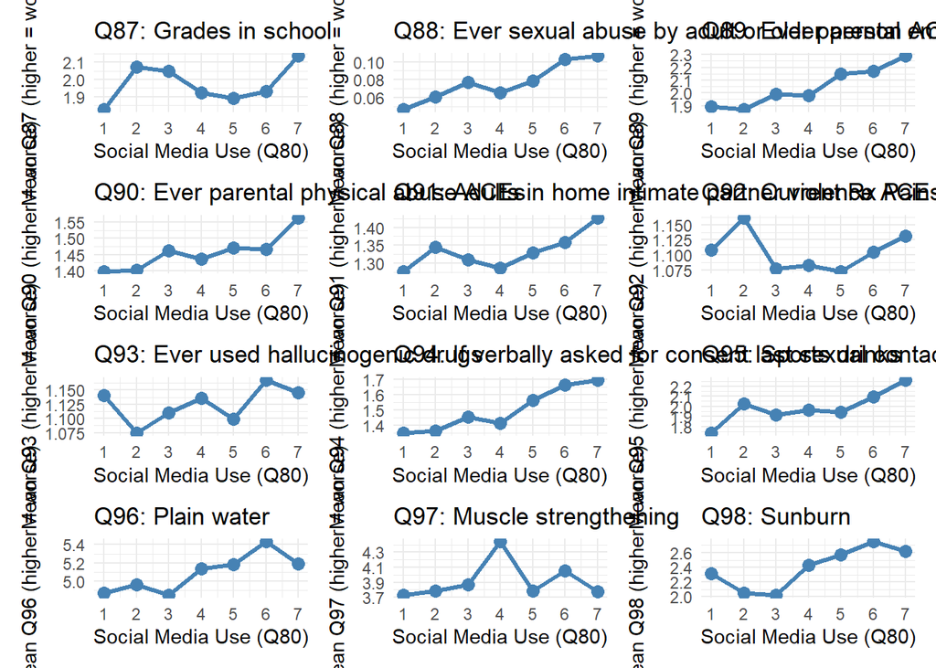

```r
current_Q_vars <- paste0("Q", 87:98)
mean_plots <- lapply(current_Q_vars, make_mean_plot)
wrap_plots(plotlist = mean_plots, ncol = 3)
```

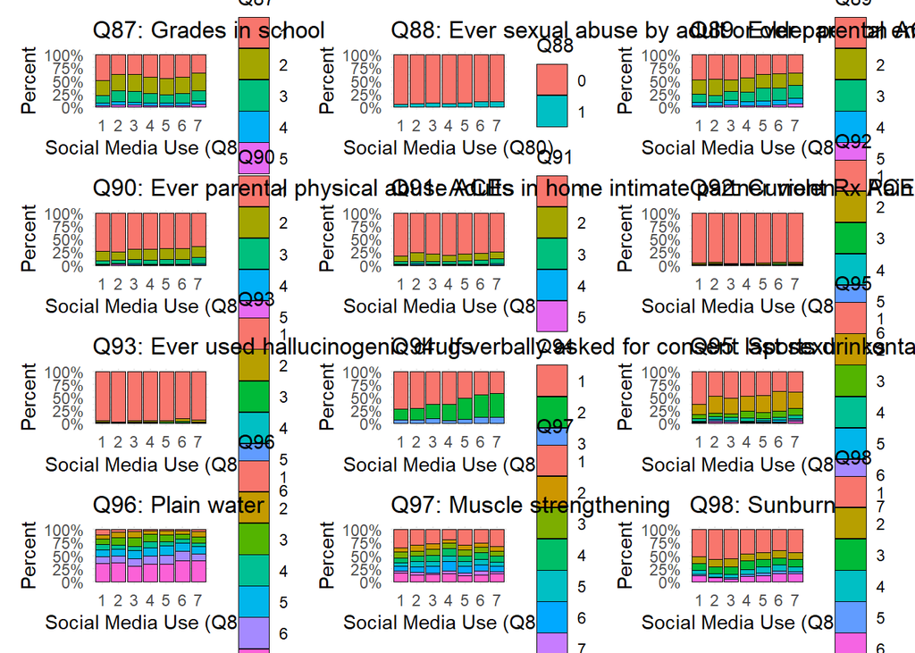

```r
stacked_plots <- lapply(current_Q_vars, function(v) {
  make_stacked_bar(v)
})

wrap_plots(plotlist = stacked_plots, ncol = 3)
```

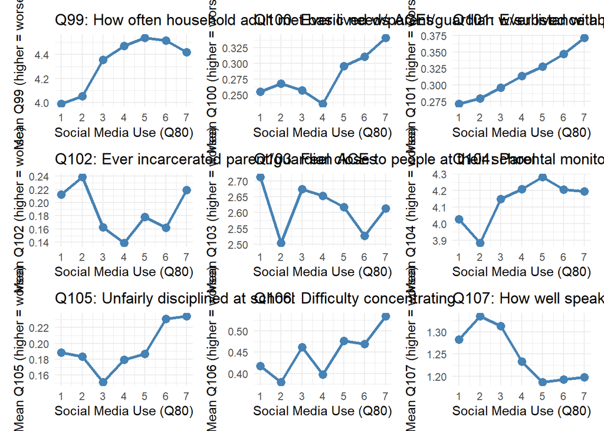

```r
current_Q_vars <- paste0("Q", 99:107)
mean_plots <- lapply(current_Q_vars, make_mean_plot)
wrap_plots(plotlist = mean_plots, ncol = 3)
```

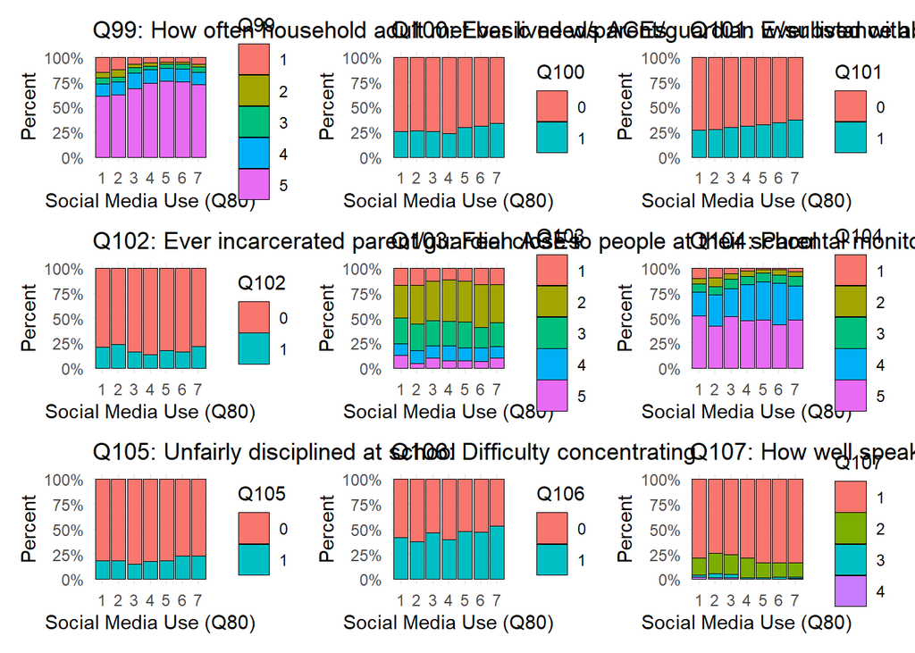

```r
stacked_plots <- lapply(current_Q_vars, function(v) {
  make_stacked_bar(v)
})

wrap_plots(plotlist = stacked_plots, ncol = 3)
```

This *MIGHT* be enough graphs. And we might not even need them all. Or maybe we do more. I was trying to avoid getting my brain stuck in regression since we’ve been talking about it in class for so long.

We should go back to the beginning of the semester and look back at some of the ways we described statistics, some of those might be more helpful for these types of problems, since when we do have slopes, they aren’t always very strong.

We also need to sometimes look at these from multiple angles, for example, in the alcohol chart, the correlations get a lot more clear when I recoded it to a binary and represented it proportionally.

A good approach might be to demonstrate which variables do/don’t have relationships with social media using the charts, then use the regression data to define and describe those relationships.